# 数据集描述

*数据集包含的是2017年所有活跃的足球运动员* *

本次数据集的来源是kesci，提供者是Ustinian*

Name 姓名  
Nationality 国籍  
National_Position 国家队位置  
National_Kit 国家队号码  
Club 所在俱乐部  
Club_Position 所在俱乐部位置  
Club_Kit 俱乐部号码  
Club_Joining 加入俱乐部时间  
Contract_Expiry 合同到期时间  
Rating 评分  
Height 身高  
Weight 体重  
Preffered_Foot 擅长左（右）脚  
Birth_Date 出生日期  
Age 年龄  
Preffered_Position 擅长位置  
Work_Rate 工作效率  
Weak_foot 非惯用脚使用频率  
Skill_Moves 技术等级  
Ball_Control 控球技术  
Dribbling 盘球（带球）能力  
Marking 盯人能力  
Sliding_Tackle 铲球  
Standing_Tackle 逼抢能力  
Aggression 攻击能力  
Reactions 反击  
Attacking_Position 攻击性跑位  
Interceptions 抢断  
Vision 视野  
Composure 镇静  
Crossing 下底传中  
Short_Pass 短传  
Long_Pass 长传  
Acceleration 加速度  
Speed 速度  
Stamina 体力  
Strength 强壮  
Balance 平衡  
Agility 敏捷度  
Jumping 跳跃  
Heading 投球  
Shot_Power 射门力量  
Finishing 射门  
Long_Shots 远射  
Curve 弧线  
Freekick_Accuracy 任意球精准度  
Penalties 点球  
Volleys 凌空能力  
GK_Positioning 门将位置感  
GK_Diving 扑救能力  
GK_Kicking 门将踢球能力  
GK_Handling 扑球脱手几率  
GK_Reflexes 门将反应度

```python
# 导入分析需要用到的库
import numpy as np
import pandas as pd
import matplotlib as mpl
import matplotlib.pyplot as plt

# 设置 matplotlib 支持中文的显示
mpl.rcParams["font.family"]="SimHei"

# 设置 matplotlib 支持负号的显示
mpl.rcParams["axes.unicode_minus"]=False
```

```python
# pandas 加载数据集FullData.csv,数据对象为player
player=pd.read_csv(r"FullData.csv")

# 显示当前所有列的数据集
pd.set_option("max_columns",100)
player.head()
```

|  | Name | Nationality | National_Position | National_Kit | Club | Club_Position | Club_Kit | Club_Joining | Contract_Expiry | Rating | Height | Weight | Preffered_Foot | Birth_Date | Age | Preffered_Position | Work_Rate | Weak_foot | Skill_Moves | Ball_Control | Dribbling | Marking | Sliding_Tackle | Standing_Tackle | Aggression | Reactions | Attacking_Position | Interceptions | Vision | … |
| --- | --- | --- | --- | --- | --- | --- | --- | --- | --- | --- | --- | --- | --- | --- | --- | --- | --- | --- | --- | --- | --- | --- | --- | --- | --- | --- | --- | --- | --- | --- |
| 0 | Cristiano Ronaldo | Portugal | LS | 7.0 | Real Madrid | LW | 7.0 | 07/01/2009 | 2021.0 | 94 | 185 cm | 80 kg | Right | 02/05/1985 | 32 | LW/ST | High / Low | 4 | 5 | 93 | 92 | 22 | 23 | 31 | 63 | 96 | 94 | 29 | 85 | … |
| 1 | Lionel Messi | Argentina | RW | 10.0 | FC Barcelona | RW | 10.0 | 07/01/2004 | 2018.0 | 93 | 170 cm | 72 kg | Left | 06/24/1987 | 29 | RW | Medium / Medium | 4 | 4 | 95 | 97 | 13 | 26 | 28 | 48 | 95 | 93 | 22 | 90 | … |
| 2 | Neymar | Brazil | LW | 10.0 | FC Barcelona | LW | 11.0 | 07/01/2013 | 2021.0 | 92 | 174 cm | 68 kg | Right | 02/05/1992 | 25 | LW | High / Medium | 5 | 5 | 95 | 96 | 21 | 33 | 24 | 56 | 88 | 90 | 36 | 80 | … |
| 3 | Luis Suárez | Uruguay | LS | 9.0 | FC Barcelona | ST | 9.0 | 07/11/2014 | 2021.0 | 92 | 182 cm | 85 kg | Right | 01/24/1987 | 30 | ST | High / Medium | 4 | 4 | 91 | 86 | 30 | 38 | 45 | 78 | 93 | 92 | 41 | 84 | … |
| 4 | Manuel Neuer | Germany | GK | 1.0 | FC Bayern | GK | 1.0 | 07/01/2011 | 2021.0 | 92 | 193 cm | 92 kg | Right | 03/27/1986 | 31 | GK | Medium / Medium | 4 | 1 | 48 | 30 | 10 | 11 | 10 | 29 | 85 | 12 | 30 | 70 | … |

```python
# 对数据集进行简单的数据查看：如缺失信息等
# 通过info方法查看缺失信息（以及每列的类型信息）
player.info()
```

```
<class 'pandas.core.frame.DataFrame'>
RangeIndex: 17588 entries, 0 to 17587
Data columns (total 53 columns):
 #   Column              Non-Null Count  Dtype
---  ------              --------------  -----
 0   Name                17588 non-null  object
 1   Nationality         17588 non-null  object
 2   National_Position   1075 non-null   object
 3   National_Kit        1075 non-null   float64
 4   Club                17588 non-null  object
 5   Club_Position       17587 non-null  object
 6   Club_Kit            17587 non-null  float64
 7   Club_Joining        17587 non-null  object
 8   Contract_Expiry     17587 non-null  float64
 9   Rating              17588 non-null  int64
```

[output cut: 45 more lines]

**通过观察可以发现，该数据集中有17588条信息，可以发现National_Position（国家队位置）和National_Kit（国家队的号码）是存在数据缺失的，其余的属性值中：Club_Position，Club_Kit，Club_Joining，Contract_Expiry也是存在缺失的**

```python
# 使用player对 Club_Position 属性这行非空的数据进行过滤，过滤完再传回给player
player=player[player["Club_Position"].notnull()]
player.info()
```

```
<class 'pandas.core.frame.DataFrame'>
Int64Index: 17587 entries, 0 to 17587
Data columns (total 53 columns):
 #   Column              Non-Null Count  Dtype
---  ------              --------------  -----
 0   Name                17587 non-null  object
 1   Nationality         17587 non-null  object
 2   National_Position   1075 non-null   object
 3   National_Kit        1075 non-null   float64
 4   Club                17587 non-null  object
 5   Club_Position       17587 non-null  object
 6   Club_Kit            17587 non-null  float64
 7   Club_Joining        17587 non-null  object
 8   Contract_Expiry     17587 non-null  float64
 9   Rating              17587 non-null  int64
```

[output cut: 45 more lines]

```python
# 查看异常值
player.describe()
```

|  | National_Kit | Club_Kit | Contract_Expiry | Rating | Age | Weak_foot | Skill_Moves | Ball_Control | Dribbling | Marking | Sliding_Tackle | Standing_Tackle | Aggression | Reactions | Attacking_Position | Interceptions | Vision | Composure | Crossing | Short_Pass | Long_Pass | Acceleration | Speed | Stamina | Strength | Balance | Agility | Jumping | Heading | … |
| --- | --- | --- | --- | --- | --- | --- | --- | --- | --- | --- | --- | --- | --- | --- | --- | --- | --- | --- | --- | --- | --- | --- | --- | --- | --- | --- | --- | --- | --- | --- |
| count | 1075.000000 | 17587.000000 | 17587.000000 | 17587.000000 | 17587.000000 | 17587.000000 | 17587.000000 | 17587.000000 | 17587.000000 | 17587.000000 | 17587.000000 | 17587.000000 | 17587.000000 | 17587.000000 | 17587.000000 | 17587.000000 | 17587.000000 | 17587.000000 | 17587.000000 | 17587.000000 | 17587.000000 | 17587.000000 | 17587.000000 | 17587.000000 | 17587.000000 | 17587.000000 | 17587.000000 | 17587.000000 | 17587.000000 | … |
| mean | 12.219535 | 21.294536 | 2018.899414 | 66.165349 | 25.459544 | 2.934042 | 2.303122 | 57.971513 | 54.801785 | 44.231592 | 45.566441 | 47.441974 | 55.918804 | 61.769546 | 49.590266 | 46.794337 | 52.706545 | 55.851766 | 49.740092 | 58.119691 | 52.395633 | 65.287940 | 65.483937 | 63.477000 | 65.084665 | 64.009268 | 63.206744 | 64.917894 | 52.391255 | … |
| std | 6.933187 | 19.163741 | 1.698787 | 7.082330 | 4.679237 | 0.655896 | 0.746159 | 16.834438 | 18.913841 | 21.561664 | 21.515428 | 21.828125 | 17.445015 | 9.274455 | 19.406193 | 20.495265 | 14.588804 | 13.485148 | 18.458043 | 14.983002 | 15.616409 | 14.436703 | 14.101011 | 15.477813 | 12.532353 | 13.720545 | 14.618579 | 11.430826 | 17.472470 | … |
| min | 1.000000 | 1.000000 | 2017.000000 | 45.000000 | 17.000000 | 1.000000 | 1.000000 | 5.000000 | 4.000000 | 3.000000 | 5.000000 | 3.000000 | 2.000000 | 29.000000 | 2.000000 | 3.000000 | 10.000000 | 5.000000 | 6.000000 | 10.000000 | 7.000000 | 11.000000 | 11.000000 | 10.000000 | 20.000000 | 10.000000 | 11.000000 | 15.000000 | 4.000000 | … |
| 25% | 6.000000 | 9.000000 | 2017.000000 | 62.000000 | 22.000000 | 3.000000 | 2.000000 | 53.000000 | 47.000000 | 22.000000 | 23.000000 | 26.000000 | 44.000000 | 55.000000 | 37.000000 | 26.000000 | 43.000000 | 47.000000 | 38.000000 | 52.000000 | 42.000000 | 57.000000 | 58.000000 | 57.000000 | 57.000000 | 56.000000 | 55.000000 | 58.000000 | 45.000000 | … |
| 50% | 12.000000 | 18.000000 | 2019.000000 | 66.000000 | 25.000000 | 3.000000 | 2.000000 | 63.000000 | 60.000000 | 48.000000 | 51.000000 | 54.000000 | 59.000000 | 62.000000 | 54.000000 | 52.000000 | 54.000000 | 57.000000 | 54.000000 | 62.000000 | 56.000000 | 68.000000 | 68.000000 | 66.000000 | 66.000000 | 65.000000 | 65.000000 | 65.000000 | 56.000000 | … |
| 75% | 18.000000 | 27.000000 | 2020.000000 | 71.000000 | 29.000000 | 3.000000 | 3.000000 | 69.000000 | 68.000000 | 64.000000 | 64.000000 | 66.000000 | 70.000000 | 68.000000 | 64.000000 | 64.000000 | 64.000000 | 66.000000 | 64.000000 | 68.000000 | 64.000000 | 75.000000 | 75.000000 | 74.000000 | 74.000000 | 74.000000 | 74.000000 | 73.000000 | 65.000000 | … |
| max | 36.000000 | 99.000000 | 2023.000000 | 94.000000 | 47.000000 | 5.000000 | 5.000000 | 95.000000 | 97.000000 | 92.000000 | 95.000000 | 92.000000 | 96.000000 | 96.000000 | 94.000000 | 93.000000 | 94.000000 | 94.000000 | 91.000000 | 92.000000 | 93.000000 | 96.000000 | 96.000000 | 95.000000 | 98.000000 | 97.000000 | 96.000000 | 95.000000 | 94.000000 | … |

**使用describe方法，可以看到对象中属性的数量count，平均值mean，标准差std，最小值min，四分之一分位点25%，中位数50%，四分之三分位点75%，最大值max。通过这种方式，可以看到数据中是否有异常点的信息**

```python
# 查看是否包含重复值
player.duplicated().any()
```

```
False
```

**检查数据集中是否有重复值</br> 调用duplicated()是用于查看当前数据中的每一行是否有重复值，返回布尔型，但是只用该方法会返回数据集中每一行是否包含重复值，显得太啰嗦，而我们只想要知道该数据集中是否存在重复值</br> 再使用any()方法（只要存在真，结果就返回true），查看整个数据集是否存在重复值。相当于对duplicated()结果中的每一行返回值，进行一个逻辑运算</br> 通过结果可以发现，我们的数据集中并无重复值**

```python
# 如果包含重复值，调用下面这条语句,inplace=True 返回的结果在player上执行，不会生成新的对象
# player.drop_duplicates(inplace=True)
```

```python
# 再次查看player对象，开始观察数据
player.head()

# 将 Height 中的cm替换成空格
player["Height"]=player["Height"].map(lambda x:int(x.replace("cm","")))
# player["Height"]=player["Height"].str.replace("cm","").astype(np.int)

# 将 Weight 中的kg替换成空格
player["Weight"]=player["Weight"].map(lambda x:int(x.replace("kg","")))
# player["Weight"]=player["Weight"].str.replace("kg","").astype(np.int)
```

```python
# 再次查看player对象
player.head()
```

|  | Name | Nationality | National_Position | National_Kit | Club | Club_Position | Club_Kit | Club_Joining | Contract_Expiry | Rating | Height | Weight | Preffered_Foot | Birth_Date | Age | Preffered_Position | Work_Rate | Weak_foot | Skill_Moves | Ball_Control | Dribbling | Marking | Sliding_Tackle | Standing_Tackle | Aggression | Reactions | Attacking_Position | Interceptions | Vision | … |
| --- | --- | --- | --- | --- | --- | --- | --- | --- | --- | --- | --- | --- | --- | --- | --- | --- | --- | --- | --- | --- | --- | --- | --- | --- | --- | --- | --- | --- | --- | --- |
| 0 | Cristiano Ronaldo | Portugal | LS | 7.0 | Real Madrid | LW | 7.0 | 07/01/2009 | 2021.0 | 94 | 185 | 80 | Right | 02/05/1985 | 32 | LW/ST | High / Low | 4 | 5 | 93 | 92 | 22 | 23 | 31 | 63 | 96 | 94 | 29 | 85 | … |
| 1 | Lionel Messi | Argentina | RW | 10.0 | FC Barcelona | RW | 10.0 | 07/01/2004 | 2018.0 | 93 | 170 | 72 | Left | 06/24/1987 | 29 | RW | Medium / Medium | 4 | 4 | 95 | 97 | 13 | 26 | 28 | 48 | 95 | 93 | 22 | 90 | … |
| 2 | Neymar | Brazil | LW | 10.0 | FC Barcelona | LW | 11.0 | 07/01/2013 | 2021.0 | 92 | 174 | 68 | Right | 02/05/1992 | 25 | LW | High / Medium | 5 | 5 | 95 | 96 | 21 | 33 | 24 | 56 | 88 | 90 | 36 | 80 | … |
| 3 | Luis Suárez | Uruguay | LS | 9.0 | FC Barcelona | ST | 9.0 | 07/11/2014 | 2021.0 | 92 | 182 | 85 | Right | 01/24/1987 | 30 | ST | High / Medium | 4 | 4 | 91 | 86 | 30 | 38 | 45 | 78 | 93 | 92 | 41 | 84 | … |
| 4 | Manuel Neuer | Germany | GK | 1.0 | FC Bayern | GK | 1.0 | 07/01/2011 | 2021.0 | 92 | 193 | 92 | Right | 03/27/1986 | 31 | GK | Medium / Medium | 4 | 1 | 48 | 30 | 10 | 11 | 10 | 29 | 85 | 12 | 30 | 70 | … |

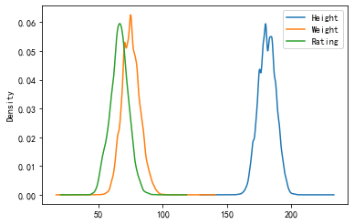

```python
# 查看运动员身高，体重，评分信息的分布图：核密度估计图kde
player[["Height","Weight","Rating"]].plot(kind="kde")
```

注意，这里Height，Weight要是没有转化成int类型，那么只有rating的一条曲线

```python
# 足球运动员左脚和右脚上的偏差：统计情况
player["Preffered_Foot"].value_counts()
```

```
Right    13493
Left      4094
Name: Preffered_Foot, dtype: int64
```

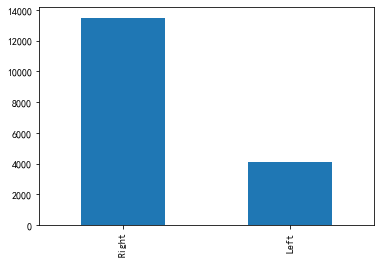

```python
# 将上面左右脚的统计结果进行画图:条形图bar
player["Preffered_Foot"].value_counts().plot(kind="bar")
```

```python
# 从球员的平均评分考虑:先根据Club分组，再获取Rating，然后对分组的内容进行计算
s=player.groupby("Club")["Rating"].agg(["count","sum","mean"])

# 对结果s进行过滤，只需要前10的内容
s=s[s["count"]>10]

# 根据count将s进行降序排序,显示前十位的结果
s.sort_values("count",ascending=False).head(10)
```

| Club | count | sum | mean |
| --- | --- | --- | --- |
| Free Agents | 232 | 15480 | 66.724138 |
| Spurs | 33 | 2410 | 73.030303 |
| Villarreal CF | 33 | 2457 | 74.454545 |
| Valencia CF | 33 | 2438 | 73.878788 |
| Middlesbrough | 33 | 2289 | 69.363636 |
| Crystal Palace | 33 | 2409 | 73.000000 |
| Stade Rennais | 33 | 2306 | 69.878788 |
| Angers SCO | 33 | 2285 | 69.242424 |
| Málaga CF | 33 | 2412 | 73.090909 |
| Arsenal | 33 | 2519 | 76.333333 |

```python
# 根据mean将s进行降序排序,显示前十位的结果
s.sort_values("mean",ascending=False).head(10)
```

| Club | count | sum | mean |
| --- | --- | --- | --- |
| Juventus | 28 | 2234 | 79.785714 |
| FC Bayern | 26 | 2057 | 79.115385 |
| Real Madrid | 33 | 2599 | 78.757576 |
| FC Barcelona | 33 | 2577 | 78.090909 |
| Napoli | 26 | 2022 | 77.769231 |
| Roma | 25 | 1944 | 77.760000 |
| Sevilla FC | 28 | 2155 | 76.964286 |
| PSG | 31 | 2378 | 76.709677 |
| Atlético Madrid | 31 | 2373 | 76.548387 |
| Arsenal | 33 | 2519 | 76.333333 |

```python
# 从球员的平均评分考虑:先根据Nationality分组，再获取Rating，然后对分组的内容进行计算
s_Nationality=player.groupby("Nationality")["Rating"].agg(["count","sum","mean"])

# 对结果s进行过滤，只需要前10的内容
s_Nationality=s_Nationality[s_Nationality["count"]>10]

# 根据mean将s进行降序排序,显示前十位的结果
s_Nationality.sort_values("mean",ascending=False).head(10)
```

| Nationality | count | sum | mean |
| --- | --- | --- | --- |
| Algeria | 50 | 3581 | 71.620000 |
| Czech Republic | 57 | 4047 | 71.000000 |
| Ecuador | 34 | 2406 | 70.764706 |
| Gabon | 15 | 1058 | 70.533333 |
| Portugal | 360 | 25329 | 70.358333 |
| Morocco | 74 | 5203 | 70.310811 |
| Paraguay | 75 | 5273 | 70.306667 |
| Spain | 1008 | 70859 | 70.296627 |
| Brazil | 921 | 64492 | 70.023887 |
| Angola | 11 | 770 | 70.000000 |

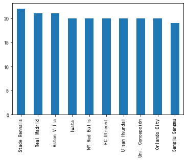

```python
# 哪个俱乐部拥有5年及其以上的球员
# 获取年份,并转化成数值类型
year=player["Club_Joining"].map(lambda x:int(x.split("/")[-1]))
# 除了用int()转化，也可以使用np.int转化
# year=year.astype(np.int)

# 获取5年以上球员的信息
t=player[(2020-year) & (player["Club"] !="Free Agents")]

# 将结果显示出来
t["Club"].value_counts().head(10).plot(kind="bar")
```

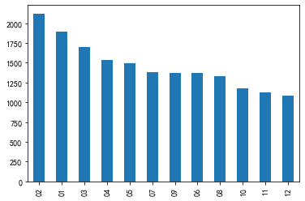

```python
# 全体运动员的出生月份与评分是否有关系
y=player["Birth_Date"].str.split("/",expand=True)
y[0].value_counts().plot(kind="bar")
```

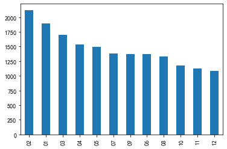

```python
# 知名运动员（评分80分以上为知名）的出生月份与评分是否有关系
y_perfect=player[player["Rating"]>=80]
y_perfect=player["Birth_Date"].str.split("/",expand=True)
y_perfect[0].value_counts().plot(kind="bar")
```

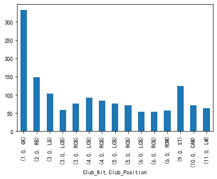

```python
# 足球运动员的号码是否与位置有关
# 去除替补球员和后备队球员
t=player[(player["Club_Position"] != "Sub" ) & (player["Club_Position"] !="Res")]

# 为了便于观察，将对应球员俱乐部的号码和位置进行分组
x=t.groupby(["Club_Kit","Club_Position"]).size()
x[x>50].plot(kind="bar")
```

**通过观察足球运动员的号码与位置的条形图，可以发现号码和位置基本上是有关系的**

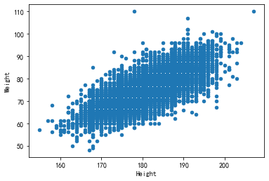

```python
# 足球运动员的身高和体重是否有关联，散点图查看
player.plot.scatter(x="Height",y="Weight")
```

**注意，这里的plot如果换成plot（）方法，是完全不一样的图</br> 通过散点图可以找到，身高和体重是线性正相关的**

```python
# 采用相关系数的方法，来观察哪些指标对数据集的影响大
player.corr()
```

|  | National_Kit | Club_Kit | Contract_Expiry | Rating | Height | Weight | Age | Weak_foot | Skill_Moves | Ball_Control | Dribbling | Marking | Sliding_Tackle | Standing_Tackle | Aggression | Reactions | Attacking_Position | Interceptions | Vision | Composure | Crossing | Short_Pass | Long_Pass | Acceleration | Speed | Stamina | Strength | Balance | Agility | … |
| --- | --- | --- | --- | --- | --- | --- | --- | --- | --- | --- | --- | --- | --- | --- | --- | --- | --- | --- | --- | --- | --- | --- | --- | --- | --- | --- | --- | --- | --- | --- |
| National_Kit | 1.000000 | 0.055408 | -0.027211 | -0.084289 | -0.101229 | -0.093795 | -0.103583 | 0.027268 | 0.105903 | 0.046644 | 0.093836 | -0.162083 | -0.152251 | -0.148329 | -0.073288 | -0.058696 | 0.124641 | -0.154804 | 0.076988 | -0.016093 | 0.045986 | 0.036071 | -0.006230 | 0.079866 | 0.056282 | 0.003828 | -0.099086 | 0.089038 | 0.085691 | … |
| Club_Kit | 0.055408 | 1.000000 | 0.077060 | -0.172710 | -0.028711 | -0.072341 | -0.198230 | -0.037234 | 0.006378 | -0.071067 | -0.028584 | -0.105522 | -0.094920 | -0.104446 | -0.121709 | -0.148887 | -0.031746 | -0.125007 | -0.071177 | -0.117220 | -0.067383 | -0.085123 | -0.100525 | -0.006315 | -0.010092 | -0.101258 | -0.141140 | 0.010762 | -0.036128 | … |
| Contract_Expiry | -0.027211 | 0.077060 | 1.000000 | 0.047430 | -0.080641 | -0.053049 | -0.118370 | 0.004865 | 0.044511 | 0.035324 | 0.048664 | 0.015409 | 0.011482 | 0.008307 | -0.010361 | 0.051309 | 0.043698 | 0.006995 | 0.028113 | 0.005840 | 0.012553 | 0.034513 | 0.016371 | 0.071003 | 0.079394 | 0.053830 | -0.012495 | 0.046095 | 0.047667 | … |
| Rating | -0.084289 | -0.172710 | 0.047430 | 1.000000 | 0.046937 | 0.139703 | 0.458098 | 0.226263 | 0.251926 | 0.463211 | 0.368565 | 0.236843 | 0.215385 | 0.249156 | 0.404422 | 0.828329 | 0.354501 | 0.319504 | 0.489277 | 0.613612 | 0.401851 | 0.496239 | 0.483217 | 0.206392 | 0.224253 | 0.355335 | 0.369045 | 0.087811 | 0.283309 | … |
| Height | -0.101229 | -0.028711 | -0.080641 | 0.046937 | 1.000000 | 0.758208 | 0.076727 | -0.180431 | -0.431177 | -0.402596 | -0.483545 | -0.042485 | -0.069602 | -0.054282 | -0.049009 | -0.016407 | -0.419544 | -0.050358 | -0.359610 | -0.169460 | -0.471327 | -0.356768 | -0.323575 | -0.521688 | -0.451128 | -0.293564 | 0.537223 | -0.799775 | -0.611198 | … |
| Weight | -0.093795 | -0.072341 | -0.053049 | 0.139703 | 0.758208 | 1.000000 | 0.223432 | -0.135402 | -0.375163 | -0.338460 | -0.412959 | -0.030512 | -0.062312 | -0.047097 | 0.017366 | 0.079019 | -0.344840 | -0.028947 | -0.283098 | -0.083541 | -0.389293 | -0.299264 | -0.261611 | -0.465558 | -0.404240 | -0.241365 | 0.613829 | -0.680791 | -0.535404 | … |
| Age | -0.103583 | -0.198230 | -0.118370 | 0.458098 | 0.076727 | 0.223432 | 1.000000 | 0.086137 | -0.016088 | 0.082875 | 0.004575 | 0.131425 | 0.096679 | 0.116847 | 0.259413 | 0.456724 | 0.073873 | 0.192667 | 0.189982 | 0.355588 | 0.134576 | 0.127537 | 0.179109 | -0.175966 | -0.168440 | 0.070685 | 0.329289 | -0.100131 | -0.019459 | … |
| Weak_foot | 0.027268 | -0.037234 | 0.004865 | 0.226263 | -0.180431 | -0.135402 | 0.086137 | 1.000000 | 0.336905 | 0.367420 | 0.363398 | 0.026950 | 0.025865 | 0.043656 | 0.134120 | 0.207098 | 0.354699 | 0.058148 | 0.352235 | 0.316486 | 0.324117 | 0.338919 | 0.298103 | 0.257156 | 0.240919 | 0.228619 | -0.004841 | 0.253466 | 0.306049 | … |
| Skill_Moves | 0.105903 | 0.006378 | 0.044511 | 0.251926 | -0.431177 | -0.375163 | -0.016088 | 0.336905 | 1.000000 | 0.727123 | 0.762623 | 0.032811 | 0.043037 | 0.070841 | 0.230424 | 0.223236 | 0.719577 | 0.067407 | 0.591623 | 0.490854 | 0.644761 | 0.628088 | 0.515631 | 0.619623 | 0.598727 | 0.469200 | -0.117029 | 0.542743 | 0.637400 | … |
| Ball_Control | 0.046644 | -0.071067 | 0.035324 | 0.463211 | -0.402596 | -0.338460 | 0.082875 | 0.367420 | 0.727123 | 1.000000 | 0.931117 | 0.355429 | 0.357025 | 0.391689 | 0.543142 | 0.424991 | 0.855487 | 0.392803 | 0.732518 | 0.704726 | 0.838775 | 0.904398 | 0.793084 | 0.669026 | 0.665755 | 0.724758 | 0.079898 | 0.573786 | 0.695569 | … |
| Dribbling | 0.093836 | -0.028584 | 0.048664 | 0.368565 | -0.483545 | -0.412959 | 0.004575 | 0.363398 | 0.762623 | 0.931117 | 1.000000 | 0.228543 | 0.243277 | 0.270005 | 0.426393 | 0.349111 | 0.888391 | 0.264903 | 0.736197 | 0.627388 | 0.848864 | 0.833578 | 0.717857 | 0.740657 | 0.725716 | 0.676495 | -0.046376 | 0.638638 | 0.754705 | … |
| Marking | -0.162083 | -0.105522 | 0.015409 | 0.236843 | -0.042485 | -0.030512 | 0.131425 | 0.026950 | 0.032811 | 0.355429 | 0.228543 | 1.000000 | 0.959955 | 0.960272 | 0.708671 | 0.218235 | 0.089095 | 0.922118 | 0.097899 | 0.327939 | 0.384596 | 0.476693 | 0.535364 | 0.138092 | 0.163242 | 0.538772 | 0.327395 | 0.117471 | 0.085645 | … |
| Sliding_Tackle | -0.152251 | -0.094920 | 0.011482 | 0.215385 | -0.069602 | -0.062312 | 0.096679 | 0.025865 | 0.043037 | 0.357025 | 0.243277 | 0.959955 | 1.000000 | 0.971730 | 0.702852 | 0.200828 | 0.097474 | 0.915207 | 0.108223 | 0.314994 | 0.400583 | 0.479273 | 0.540317 | 0.159178 | 0.181316 | 0.538313 | 0.287903 | 0.145242 | 0.103459 | … |
| Standing_Tackle | -0.148329 | -0.104446 | 0.008307 | 0.249156 | -0.054282 | -0.047097 | 0.116847 | 0.043656 | 0.070841 | 0.391689 | 0.270005 | 0.960272 | 0.971730 | 1.000000 | 0.728240 | 0.230117 | 0.130957 | 0.930060 | 0.143787 | 0.353054 | 0.417381 | 0.514137 | 0.567442 | 0.158883 | 0.182390 | 0.561885 | 0.321261 | 0.139473 | 0.110567 | … |
| Aggression | -0.073288 | -0.121709 | -0.010361 | 0.404422 | -0.049009 | 0.017366 | 0.259413 | 0.134120 | 0.230424 | 0.543142 | 0.426393 | 0.708671 | 0.702852 | 0.728240 | 1.000000 | 0.390453 | 0.371589 | 0.736112 | 0.312152 | 0.534981 | 0.476202 | 0.597913 | 0.583940 | 0.260563 | 0.291840 | 0.643250 | 0.450040 | 0.172027 | 0.239329 | … |
| Reactions | -0.058696 | -0.148887 | 0.051309 | 0.828329 | -0.016407 | 0.079019 | 0.456724 | 0.207098 | 0.223236 | 0.424991 | 0.349111 | 0.218235 | 0.200828 | 0.230117 | 0.390453 | 1.000000 | 0.373846 | 0.318822 | 0.482080 | 0.589313 | 0.381557 | 0.457700 | 0.444277 | 0.183576 | 0.188701 | 0.346043 | 0.290929 | 0.130092 | 0.283719 | … |
| Attacking_Position | 0.124641 | -0.031746 | 0.043698 | 0.354501 | -0.419544 | -0.344840 | 0.073873 | 0.354699 | 0.719577 | 0.855487 | 0.888391 | 0.089095 | 0.097474 | 0.130957 | 0.371589 | 0.373846 | 1.000000 | 0.146484 | 0.738465 | 0.612847 | 0.771688 | 0.749769 | 0.612211 | 0.666267 | 0.656369 | 0.629698 | -0.002622 | 0.565325 | 0.690857 | … |
| Interceptions | -0.154804 | -0.125007 | 0.006995 | 0.319504 | -0.050358 | -0.028947 | 0.192667 | 0.058148 | 0.067407 | 0.392803 | 0.264903 | 0.922118 | 0.915207 | 0.930060 | 0.736112 | 0.318822 | 0.146484 | 1.000000 | 0.180741 | 0.386457 | 0.417610 | 0.516755 | 0.578525 | 0.152006 | 0.170350 | 0.566760 | 0.342730 | 0.138773 | 0.126500 | … |
| Vision | 0.076988 | -0.071177 | 0.028113 | 0.489277 | -0.359610 | -0.283098 | 0.189982 | 0.352235 | 0.591623 | 0.732518 | 0.736197 | 0.097899 | 0.108223 | 0.143787 | 0.312152 | 0.482080 | 0.738465 | 0.180741 | 1.000000 | 0.648886 | 0.688579 | 0.728223 | 0.699200 | 0.457209 | 0.431337 | 0.482344 | -0.035903 | 0.476798 | 0.594925 | … |
| Composure | -0.016093 | -0.117220 | 0.005840 | 0.613612 | -0.169460 | -0.083541 | 0.355588 | 0.316486 | 0.490854 | 0.704726 | 0.627388 | 0.327939 | 0.314994 | 0.353054 | 0.534981 | 0.589313 | 0.612847 | 0.386457 | 0.648886 | 1.000000 | 0.594509 | 0.704532 | 0.659843 | 0.385533 | 0.391405 | 0.544327 | 0.258847 | 0.329439 | 0.463008 | … |
| Crossing | 0.045986 | -0.067383 | 0.012553 | 0.401851 | -0.471327 | -0.389293 | 0.134576 | 0.324117 | 0.644761 | 0.838775 | 0.848864 | 0.384596 | 0.400583 | 0.417381 | 0.476202 | 0.381557 | 0.771688 | 0.417610 | 0.688579 | 0.594509 | 1.000000 | 0.811867 | 0.764061 | 0.650463 | 0.638415 | 0.667137 | -0.032359 | 0.593965 | 0.681712 | … |
| Short_Pass | 0.036071 | -0.085123 | 0.034513 | 0.496239 | -0.356768 | -0.299264 | 0.127537 | 0.338919 | 0.628088 | 0.904398 | 0.833578 | 0.476693 | 0.479273 | 0.514137 | 0.597913 | 0.457700 | 0.749769 | 0.516755 | 0.728223 | 0.704532 | 0.811867 | 1.000000 | 0.900749 | 0.558926 | 0.555353 | 0.708465 | 0.118579 | 0.515630 | 0.606182 | … |
| Long_Pass | -0.006230 | -0.100525 | 0.016371 | 0.483217 | -0.323575 | -0.261611 | 0.179109 | 0.298103 | 0.515631 | 0.793084 | 0.717857 | 0.535364 | 0.540317 | 0.567442 | 0.583940 | 0.444277 | 0.612211 | 0.578525 | 0.699200 | 0.659843 | 0.764061 | 0.900749 | 1.000000 | 0.443544 | 0.435200 | 0.632998 | 0.108879 | 0.450968 | 0.522242 | … |
| Acceleration | 0.079866 | -0.006315 | 0.071003 | 0.206392 | -0.521688 | -0.465558 | -0.175966 | 0.257156 | 0.619623 | 0.669026 | 0.740657 | 0.138092 | 0.159178 | 0.158883 | 0.260563 | 0.183576 | 0.666267 | 0.152006 | 0.457209 | 0.385533 | 0.650463 | 0.558926 | 0.443544 | 1.000000 | 0.922681 | 0.612846 | -0.164064 | 0.681551 | 0.792586 | … |
| Speed | 0.056282 | -0.010092 | 0.079394 | 0.224253 | -0.451128 | -0.404240 | -0.168440 | 0.240919 | 0.598727 | 0.665755 | 0.725716 | 0.163242 | 0.181316 | 0.182390 | 0.291840 | 0.188701 | 0.656369 | 0.170350 | 0.431337 | 0.391405 | 0.638415 | 0.555353 | 0.435200 | 0.922681 | 1.000000 | 0.627496 | -0.085941 | 0.619552 | 0.748592 | … |
| Stamina | 0.003828 | -0.101258 | 0.053830 | 0.355335 | -0.293564 | -0.241365 | 0.070685 | 0.228619 | 0.469200 | 0.724758 | 0.676495 | 0.538772 | 0.538313 | 0.561885 | 0.643250 | 0.346043 | 0.629698 | 0.566760 | 0.482344 | 0.544327 | 0.667137 | 0.708465 | 0.632998 | 0.612846 | 0.627496 | 1.000000 | 0.230247 | 0.458269 | 0.557333 | … |
| Strength | -0.099086 | -0.141140 | -0.012495 | 0.369045 | 0.537223 | 0.613829 | 0.329289 | -0.004841 | -0.117029 | 0.079898 | -0.046376 | 0.327395 | 0.287903 | 0.321261 | 0.450040 | 0.290929 | -0.002622 | 0.342730 | -0.035903 | 0.258847 | -0.032359 | 0.118579 | 0.108879 | -0.164064 | -0.085941 | 0.230247 | 1.000000 | -0.419046 | -0.243772 | … |
| Balance | 0.089038 | 0.010762 | 0.046095 | 0.087811 | -0.799775 | -0.680791 | -0.100131 | 0.253466 | 0.542743 | 0.573786 | 0.638638 | 0.117471 | 0.145242 | 0.139473 | 0.172027 | 0.130092 | 0.565325 | 0.138773 | 0.476798 | 0.329439 | 0.593965 | 0.515630 | 0.450968 | 0.681551 | 0.619552 | 0.458269 | -0.419046 | 1.000000 | 0.748228 | … |
| Agility | 0.085691 | -0.036128 | 0.047667 | 0.283309 | -0.611198 | -0.535404 | -0.019459 | 0.306049 | 0.637400 | 0.695569 | 0.754705 | 0.085645 | 0.103459 | 0.110567 | 0.239329 | 0.283719 | 0.690857 | 0.126500 | 0.594925 | 0.463008 | 0.681712 | 0.606182 | 0.522242 | 0.792586 | 0.748592 | 0.557333 | -0.243772 | 0.748228 | 1.000000 | … |
| Jumping | -0.100935 | -0.106797 | 0.002805 | 0.289840 | -0.063048 | 0.005842 | 0.168694 | 0.064655 | 0.035166 | 0.172802 | 0.117374 | 0.258669 | 0.254936 | 0.255130 | 0.352169 | 0.260403 | 0.116465 | 0.279615 | 0.054090 | 0.243641 | 0.117779 | 0.174645 | 0.141914 | 0.209320 | 0.232382 | 0.331521 | 0.268866 | 0.167705 | 0.208837 | … |
| Heading | -0.072020 | -0.076264 | 0.026235 | 0.343265 | 0.005367 | 0.019235 | 0.137785 | 0.190847 | 0.391626 | 0.658111 | 0.548257 | 0.546994 | 0.523946 | 0.555447 | 0.677640 | 0.305042 | 0.532394 | 0.536809 | 0.305804 | 0.542475 | 0.482777 | 0.632108 | 0.518379 | 0.345955 | 0.398331 | 0.640626 | 0.458370 | 0.157088 | 0.266705 | … |
| Shot_Power | 0.083610 | -0.051829 | 0.021477 | 0.441773 | -0.273413 | -0.188739 | 0.151174 | 0.334897 | 0.640183 | 0.829902 | 0.795016 | 0.219159 | 0.217468 | 0.256805 | 0.496297 | 0.404946 | 0.795237 | 0.264911 | 0.679237 | 0.673363 | 0.704200 | 0.771737 | 0.679311 | 0.538325 | 0.548975 | 0.620266 | 0.172875 | 0.429301 | 0.563776 | … |
| Finishing | 0.138914 | -0.007898 | 0.032341 | 0.328576 | -0.347154 | -0.281775 | 0.064487 | 0.361983 | 0.715228 | 0.781218 | 0.817034 | -0.096066 | -0.098796 | -0.058670 | 0.230695 | 0.316802 | 0.880495 | -0.044888 | 0.695177 | 0.562688 | 0.644380 | 0.653929 | 0.507594 | 0.591831 | 0.582587 | 0.495899 | -0.012010 | 0.486708 | 0.627152 | … |
| Long_Shots | 0.109168 | -0.040658 | 0.028781 | 0.419517 | -0.364182 | -0.274446 | 0.149635 | 0.365637 | 0.680434 | 0.831846 | 0.836080 | 0.116621 | 0.117163 | 0.156849 | 0.386260 | 0.408545 | 0.850896 | 0.181337 | 0.754865 | 0.642917 | 0.740554 | 0.761394 | 0.674009 | 0.571502 | 0.558026 | 0.591168 | 0.045462 | 0.504732 | 0.637318 | … |
| Curve | 0.081888 | -0.053631 | 0.010840 | 0.420796 | -0.423115 | -0.343380 | 0.139101 | 0.359044 | 0.689265 | 0.832009 | 0.840061 | 0.206493 | 0.216875 | 0.247088 | 0.395877 | 0.405543 | 0.804621 | 0.260755 | 0.750496 | 0.641637 | 0.826872 | 0.779465 | 0.716427 | 0.595826 | 0.576378 | 0.586883 | -0.036263 | 0.558874 | 0.668396 | … |
| Freekick_Accuracy | 0.106621 | -0.062077 | 0.007001 | 0.399575 | -0.380217 | -0.293956 | 0.195338 | 0.345745 | 0.634867 | 0.763315 | 0.750014 | 0.233461 | 0.241188 | 0.274715 | 0.402368 | 0.390557 | 0.727188 | 0.292869 | 0.718754 | 0.606544 | 0.761017 | 0.742423 | 0.710268 | 0.486247 | 0.462375 | 0.537091 | -0.003688 | 0.493454 | 0.577702 | … |
| Penalties | 0.095289 | -0.016220 | 0.020878 | 0.339898 | -0.321246 | -0.246189 | 0.131469 | 0.340757 | 0.662108 | 0.767803 | 0.765259 | 0.062951 | 0.059355 | 0.096483 | 0.329841 | 0.333713 | 0.798127 | 0.104781 | 0.647055 | 0.590273 | 0.648078 | 0.675478 | 0.550959 | 0.522338 | 0.515824 | 0.516367 | 0.052389 | 0.453402 | 0.552681 | … |
| Volleys | 0.117381 | -0.020482 | 0.025120 | 0.386494 | -0.333576 | -0.258932 | 0.133950 | 0.366610 | 0.701017 | 0.789287 | 0.804633 | 0.013556 | 0.015133 | 0.053435 | 0.318366 | 0.382709 | 0.841600 | 0.071093 | 0.700223 | 0.622623 | 0.684915 | 0.691174 | 0.569566 | 0.563226 | 0.555322 | 0.523170 | 0.022775 | 0.484856 | 0.616572 | … |
| GK_Positioning | -0.031492 | 0.004684 | -0.027994 | -0.018586 | 0.358795 | 0.342502 | 0.122371 | -0.232109 | -0.607676 | -0.776117 | -0.741793 | -0.492932 | -0.498386 | -0.521127 | -0.561675 | -0.039962 | -0.665015 | -0.470613 | -0.400721 | -0.462405 | -0.658450 | -0.714431 | -0.595199 | -0.589681 | -0.600348 | -0.702177 | -0.079647 | -0.484823 | -0.507581 | … |
| GK_Diving | -0.012435 | 0.011290 | -0.026117 | -0.027615 | 0.357683 | 0.340775 | 0.105158 | -0.236372 | -0.610500 | -0.779922 | -0.743848 | -0.496354 | -0.501643 | -0.524291 | -0.567497 | -0.048234 | -0.668924 | -0.474997 | -0.405353 | -0.470743 | -0.662598 | -0.717572 | -0.598739 | -0.589198 | -0.599891 | -0.705673 | -0.085167 | -0.484486 | -0.508065 | … |
| GK_Kicking | -0.015472 | 0.008788 | -0.023273 | -0.031696 | 0.356070 | 0.339505 | 0.109931 | -0.230924 | -0.605746 | -0.775690 | -0.739995 | -0.495732 | -0.501019 | -0.523387 | -0.563989 | -0.051864 | -0.663450 | -0.473268 | -0.398335 | -0.468175 | -0.658385 | -0.713856 | -0.594084 | -0.589036 | -0.599152 | -0.702016 | -0.084113 | -0.484118 | -0.508568 | … |
| GK_Handling | -0.024611 | 0.006725 | -0.023064 | -0.021343 | 0.359746 | 0.341829 | 0.113216 | -0.233080 | -0.606713 | -0.775632 | -0.740616 | -0.496431 | -0.501429 | -0.523648 | -0.564734 | -0.044558 | -0.664273 | -0.474025 | -0.397728 | -0.464087 | -0.658085 | -0.714071 | -0.594416 | -0.589799 | -0.599809 | -0.703375 | -0.080986 | -0.487582 | -0.506763 | … |
| GK_Reflexes | -0.018816 | 0.007480 | -0.024923 | -0.022978 | 0.360260 | 0.341785 | 0.106979 | -0.235275 | -0.609282 | -0.777668 | -0.742065 | -0.497013 | -0.501738 | -0.524598 | -0.566184 | -0.045050 | -0.666512 | -0.474850 | -0.401582 | -0.469048 | -0.661232 | -0.716827 | -0.597275 | -0.588293 | -0.599522 | -0.705185 | -0.084108 | -0.485658 | -0.507833 | … |

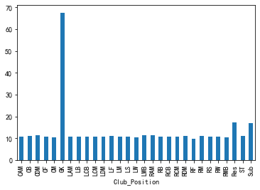

```python
# 假设不知到数据集中后两行的含义，由数据集的特征来推断GK_Handling
#player.info()

# 现根据 Club_Position 对其进行分组
t=player.groupby("Club_Position")

# 获取分组后GK_Handling的均值情况，条形图展示
t["GK_Handling"].agg("mean").plot(kind="bar")
```

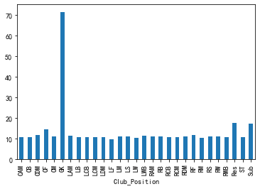

```python
# 假设不知到数据集中后两行的含义，由数据集的特征来推断GK_Reflexes
#player.info()

# 现根据 Club_Position 对其进行分组
t=player.groupby("Club_Position")

# 获取分组后GK_Handling的均值情况，条形图展示
t["GK_Reflexes"].agg("mean").plot(kind="bar")
```

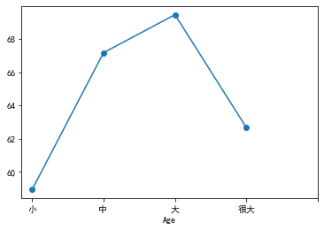

```python
# 观察年龄与评分之间的关系
t=player[["Age","Rating"]]

# 使用pandas将年龄Age进行离散化
t["Age"]=pd.cut(player["Age"],bins=[0,20,30,40,60],labels=["小","中","大","很大"])

# 根据t的年龄进行分组，得到评分的均值
t.groupby("Age")["Rating"].mean().plot(kind="line",xticks=[0,1,2,3,4],marker="o")
```

**总结</br>** 1.这篇文章主要是关于足球运动员数据集的一个分析,所作的工作仅是对数据的一个分析，重点在于熟悉python的数据分析方法</br> 2.首先是对数据的预处理：缺失信息处理（过滤，补全），异常值处理，重复值处理</br> 3.对想要调查的数据进行数据分析，画出相关的图：条形图bar，线性图line，散点图，核密度估计图kde</br>

同样数据，采用机器学习的方法对其进行分析链接